# Developing Data Products

1/26/2018

## Overview

This was built for the Course project in Developing Data Products as part of the Coursera Data Science Specialization.

The app developed for the first part of the assignment is avalilable at: https://benstraub.shinyapps.io/Shiny_Part_KRR/

Source code for ui.R and server.R files are available on the GitHub repo: https://github.com/bms63/Shiny_Part_KRR

## Application Functionality

The site provides a brief and simple example of kernel regularized least squares.

**Description:** The App leverages the package KLRS, which implements Kernel-based Regularized Least Squares (KRLS), a machine learning method to fit multidimensional functions y=f(x) for regression and classification problems without relying on linearity or additivity assumptions. KRLS finds the best fitting function by minimizing the squared loss of a Tikhonov regularization problem, using Gaussian kernels as radial basis functions. For further details see Hainmueller and Hazlett (2014).

Data is generated from a \(cos(x)+sin(x)\) on the interval \((-4\pi, 4\pi)\).

The task for the user is to explore different pairs of lambda, \(\lambda\), and sigma,\(\sigma\), to recreate the curve from the plotted data.

## \(\lambda = 3, \sigma=2\)

Here the orginal curve is in black and the curve created by kernel regularized least squares is in red.

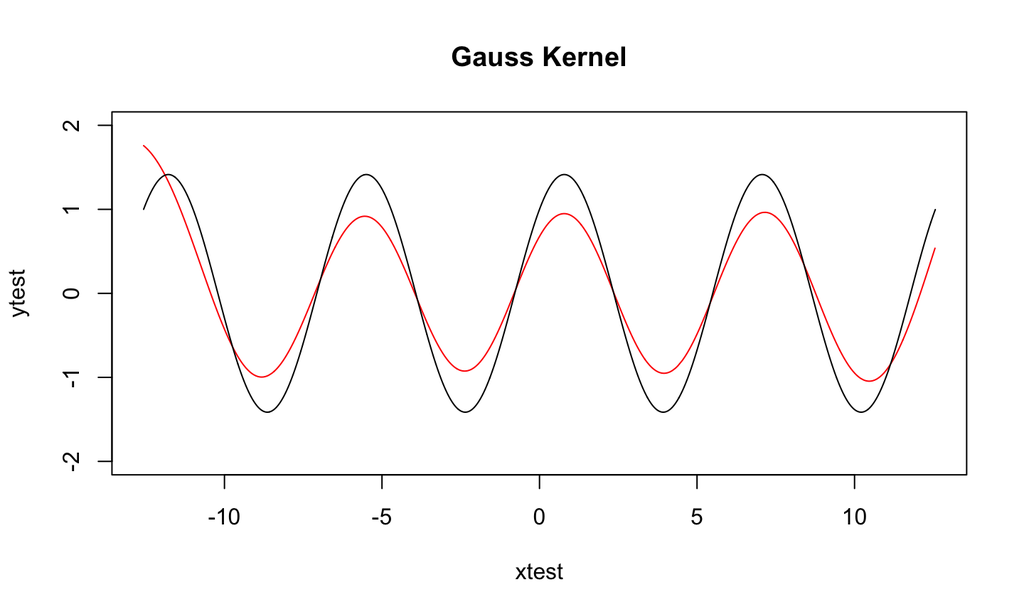

## Try it out

It's pretty cool that our least squares methods when using the kernel method can recreate a \(cos(x) + sin(x)\) curve!!

Now give it a try on the shiny app! Thanks!

https://benstraub.shinyapps.io/Shiny_Part_KRR/